# Homeworks 11 & 12

Batch processing & ggplot

Thomas O’Leary

# Homework 11: Batch processing

## Assignment

Repeat the exercise from the Batch Processing Lecture (7th April), but do it using real data sets rather than purely simulated. Check with folks in your lab to see if there are multiple data sets available for analysis. Stick to simple data analyses and graphics, but try to set it up as a batch process that will work on multiple files and save summary results to a common file.

## Data notes

For this homework, I am taking spec data from **Gretchen Thompson**’s honors thesis measuring ADH activity in natural populations of *D. melanogaster* and laboratory lines of *D. melanogaster* that have known fast ands slow isoforms of the enzyme.

- Ultimately Gretchen was trying to determine the K<sub>m</sub>’s of each of the enzymes at different temperatures.
- This type of data and analysis is prime fodder for batch processing as the spec spits out many absorbance values for a bunch of samples at several time points.
  - Here I am loading several `.csv` files from a directory that has files from different temperatures and different concentrations.
- Reaction velocity must be calculated based on linear regressions of the change in absorbance over time.
- A Michaelis–Menten curve needs be fitted on the reaction velocities at each concentration, to find V<sub>max</sub> and K<sub>m</sub> values.
- Hopefully, a version of this pipeline will be useful in the future.

## Functions

```r
# ------------------------------------------------------------------------------
# Batch processing spec data
# April 16, 2020
# TS O'Leary
# ------------------------------------------------------------------------------


# ------------------------------------------------------------------------------
# Function: read_tidy_spec_csv
# Description: uses read_csv and tidys the data
# Inputs: .csv file
# Outputs: data.frame

require(tidyverse)

read_tidy_spec_csv <- function(file) {

  read_csv(file) %>%
    pivot_longer(-c("cycle", "time", "temp"),
                 names_to = "conc",
                 values_to = "abs") %>%
    mutate(conc = as.numeric(str_replace_all(conc, "_.", ""))) %>%
    mutate(file = file,
           temp_group = case_when(temp > 17.5 & temp < 19.5 ~ "18.5",
                                  temp > 22.5 & temp < 24.5 ~ "23.5",
                                  temp > 27.5 & temp < 29.5 ~ "28.5",
                                  temp > 32.5 & temp < 34.5 ~ "33.5",
                                  temp > 37.5 & temp < 39.5 ~ "38.5"))

}
# End function -----------------------------------------------------------------


# ------------------------------------------------------------------------------
# Function: read_bind_tidy_csv
# Description: Read all the spec csvs in a directory
# Inputs: dir is the directory with csv files to load and bind
# Outputs: large binded tibble

require(tidyverse)

read_bind_tidy_csv <- function(dir) {
  setwd(dir)
  files <- list.files()
  dfs <- vector(mode = "list", length = length(files))

    for (i in seq_along(files)){
      dfs[[i]] <- read_tidy_spec_csv(files[i])
    }

  bind_rows(dfs)
}
# End function -----------------------------------------------------------------


# ------------------------------------------------------------------------------
# Function: calc_velocity
# Description: Linear regression to determine velocity of the reaction in
#              absorbance over time at each conc for each temp_group
# Inputs: tibble from read_bind_tidy_csv() with conc, temp_group,
#         abs, & time columns
# Outputs: tibble with velocity estimates

require(tidyverse)
require(broom)

calc_velocity <- function(data) {
  data %>%
    group_by(conc, temp_group) %>%
    nest() %>%
    mutate(
      fit = map(data, ~ lm(abs ~ time, data = .x)),
      tidied = map(fit, tidy)
    ) %>%
    unnest(tidied) %>%
    filter(term == "time" & conc != "0" & estimate > 0) %>%
    select(temp_group, conc, estimate) %>%
    rename(velocity = estimate)
}
# End function -----------------------------------------------------------------


# ------------------------------------------------------------------------------
# Function: calc_Km_Vm
# Description: Calculate Vmax and Km for Michaelis–Menten curve
# Inputs: tibble with velocity estimates for each conc and temp_group
# Outputs: tibble with estimates for Vmax and Km

require(tidyverse)
require(broom)

calc_Km_Vm <- function(data) {
  data %>%
    filter(conc != 0 & velocity > 0) %>%
    group_by(temp_group) %>%
    nest() %>%
    mutate(
      fit = map(data, ~ nls(formula =
                              velocity ~ SSmicmen(conc, Vmax, Km), data = .),
                data = .x),
      tidied = map(fit, tidy)
    ) %>%
    unnest(tidied)
}
# End function -----------------------------------------------------------------
```

## Program body

```r
# Load packages
require(tidyverse)
require(broom)
require(RColorBrewer)

# Calculate reaction velocities at each [EtOH] and each Temp group -------------
# Determine the Km and Vmax from the fit of the Michaelis–Menten curves --------

# ADH-fast enzyme
data_f <- read_bind_tidy_csv(dir = here::here("Homework/spec_data/adh-f"))
head(data_f)
```

```
## # A tibble: 6 x 7
##   cycle  time  temp  conc   abs file                  temp_group
##   <dbl> <dbl> <dbl> <dbl> <dbl> <chr>                 <chr>
## 1     1     0  18.5   0   0.117 adh-f_march_17_01.csv 18.5
## 2     1     0  18.5   0   0.115 adh-f_march_17_01.csv 18.5
## 3     1     0  18.5   0   0.128 adh-f_march_17_01.csv 18.5
## 4     1     0  18.5   1.5 0.299 adh-f_march_17_01.csv 18.5
## 5     1     0  18.5   1.5 0.287 adh-f_march_17_01.csv 18.5
## 6     1     0  18.5   1.5 0.314 adh-f_march_17_01.csv 18.5
```

```r
data_velo_f <- calc_velocity(data_f)
data_velo_f
```

```
## # A tibble: 55 x 3
## # Groups:   conc, temp_group [55]
##    temp_group  conc velocity
##    <chr>      <dbl>    <dbl>
##  1 18.5         1.5 0.000245
##  2 18.5         3   0.000157
##  3 18.5         6   0.000262
##  4 18.5        12.5 0.000425
##  5 18.5        25   0.000557
##  6 18.5        50   0.000765
##  7 18.5       100   0.000965
##  8 18.5       200   0.00117
##  9 18.5       400   0.00133
## 10 18.5       800   0.00148
## # … with 45 more rows
```

```r
data_Km_Vm_f <- calc_Km_Vm(data_velo_f)
data_Km_Vm_f
```

```
## # A tibble: 10 x 8
## # Groups:   temp_group [5]
##    temp_group           data fit    term  estimate std.error statistic  p.value
##    <chr>      <list<df[,2]>> <list> <chr>    <dbl>     <dbl>     <dbl>    <dbl>
##  1 18.5             [11 × 2] <nls>  Vmax   0.00152 0.0000619     24.5  1.50e- 9
##  2 18.5             [11 × 2] <nls>  Km    44.5     7.71           5.77 2.69e- 4
##  3 23.5             [11 × 2] <nls>  Vmax   0.00175 0.0000607     28.9  3.47e-10
##  4 23.5             [11 × 2] <nls>  Km    55.9     7.92           7.07 5.87e- 5
##  5 28.5             [11 × 2] <nls>  Vmax   0.00193 0.0000639     30.2  2.35e-10
##  6 28.5             [11 × 2] <nls>  Km    61.5     8.19           7.50 3.68e- 5
##  7 33.5             [11 × 2] <nls>  Vmax   0.00204 0.0000633     32.3  1.30e-10
##  8 33.5             [11 × 2] <nls>  Km    61.3     7.65           8.02 2.18e- 5
##  9 38.5             [11 × 2] <nls>  Vmax   0.00215 0.0000801     26.8  6.78e-10
## 10 38.5             [11 × 2] <nls>  Km    51.9     8.01           6.47 1.15e- 4
```

```r
# ADH-slow enzyme
data_s <- read_bind_tidy_csv(dir = here::here("Homework/spec_data/adh-s")) %>%
  filter(str_detect(file, "deg"))
data_velo_s <- calc_velocity(data_s)
data_Km_Vm_s <- calc_Km_Vm(data_velo_s)

# VTECK8 ADH enzyme
data_vt <- read_bind_tidy_csv(dir = here::here("Homework/spec_data/vt")) %>%
  filter(str_detect(file, "deg"))
data_velo_vt <- calc_velocity(data_vt)
data_Km_Vm_vt <- calc_Km_Vm(data_velo_vt)

# Chiapas ADH enzyme
data_chiapas <- read_bind_tidy_csv(dir = here::here("Homework/spec_data/chiapas")) %>%
  filter(str_detect(file, "deg") & !is.na(abs))
data_velo_chiapas <- calc_velocity(data_chiapas)
data_Km_Vm_chiapas <- calc_Km_Vm(data_velo_chiapas)
```

# Homework 12: Advanced ggplotting

For this exerise, use your newly-developed ggplot chops to create some nice graphs from your own data (If you do not have a good data frame to use for graphics, use one of the many built-in data frames from R (other than mpg, which we are using in class)). Experiment with different themes, theme base sizes, aesthetics, mappings, and faceting. When you are finished, try exporting them to high quality pdfs, jpgs, eps files, or other formats that you would use for submission to a journal.

## Functions

```r
# Plotting functions

# ------------------------------------------------------------------------------
# Function: plot_mm_curve
# Description: Plot the Michaelis-Menten curves
# Inputs: tibble with conc and velocity columns
# Outputs: plot

require(tidyverse)

plot_mm_curve <- function(data,
                          palette = c("skyblue", "blue", "purple", "red", "darkred")) {

  ggplot(data, aes(x = conc, y = velocity, fill = temp_group)) +
    geom_point(pch = 21, size = 3, color = "grey50", alpha = 0.75) +
    geom_smooth(method = "nls",
                formula = y ~ SSmicmen(x, Vmax, Km),
                data = data,
                se = FALSE,
                aes(color = temp_group),
                show.legend = FALSE) +
    scale_fill_manual(name = "Temperature",
                      values = palette,
                      labels = c("18.5°C",
                                 "23.5°C",
                                 "28.5°C",
                                 "33.5°C",
                                 "38.5°C")) +
    scale_color_manual(values = palette) +
    labs(x = "Ethanol (mM)",
         y = expression("Reaction Velocity (Abs/sec)")) +
    theme_classic()
}
# End function -----------------------------------------------------------------


# ------------------------------------------------------------------------------
# Function: plot_km
# Description: Plot km values with std.error bars
# Inputs: tibble with Km estimate and error
# Outputs: plot

require(tidyverse)

plot_km <- function(data,
                    palette = brewer.pal(4, "Set2"),
                    legend.labels = c( "VT-ECK 8", "Chiapas", "Fast", "Slow")) {
  ggplot(data, aes(x = temp_group, y = estimate_Km, fill = enzyme)) +
    geom_errorbar(aes(ymin = estimate_Km - std.error_Km,
                      ymax = estimate_Km + std.error_Km),
                  width = .2,
                  position = position_dodge(0.5)) +
    geom_point(pch = 21, position = position_dodge(0.5), size = 6) +
    labs(x = "Temperature (°C)",
         y = expression("K"[m]*"  (mM EtOH)")) +
    scale_fill_manual(name = "ADH enzyme",
                      values = palette,
                      labels = legend.labels) +
    theme_classic()
}
# End function -----------------------------------------------------------------
```

## Michaelis–Menten curves

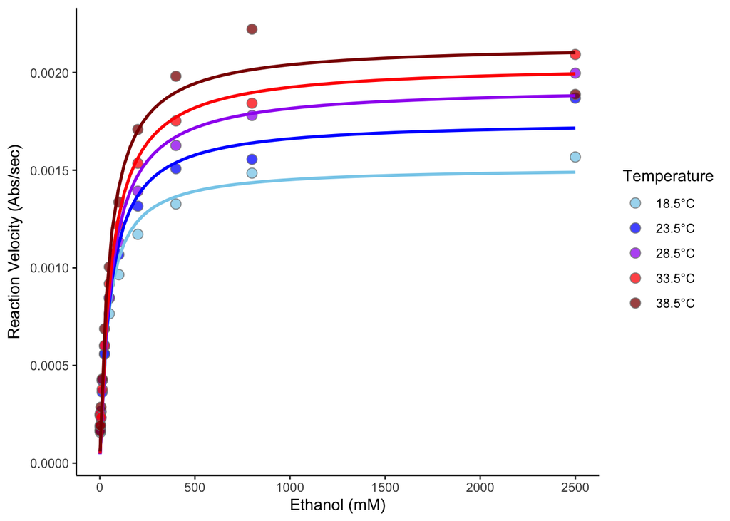

```r
# ADH-fast enzyme
plot_mm_curve(data_velo_f)
```

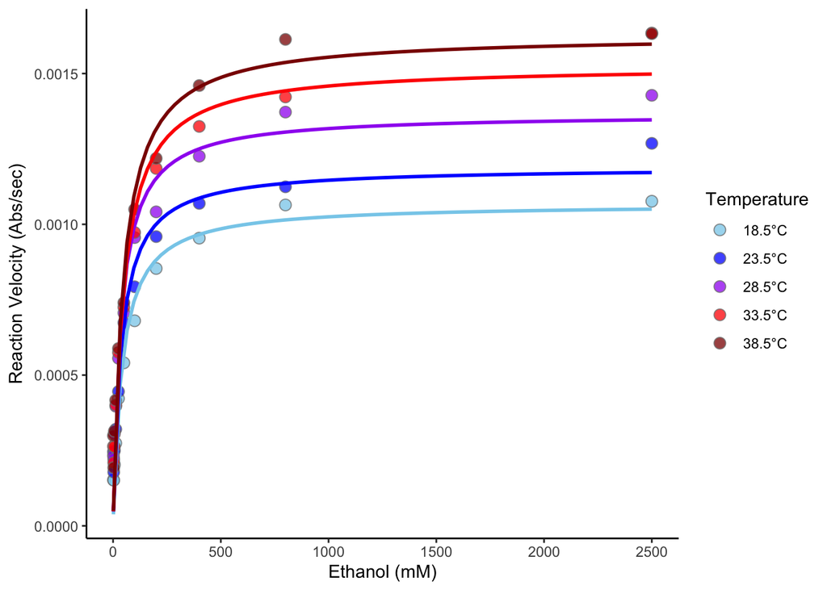

```r
# ADH-slow enzyme
plot_mm_curve(data_velo_s)
```

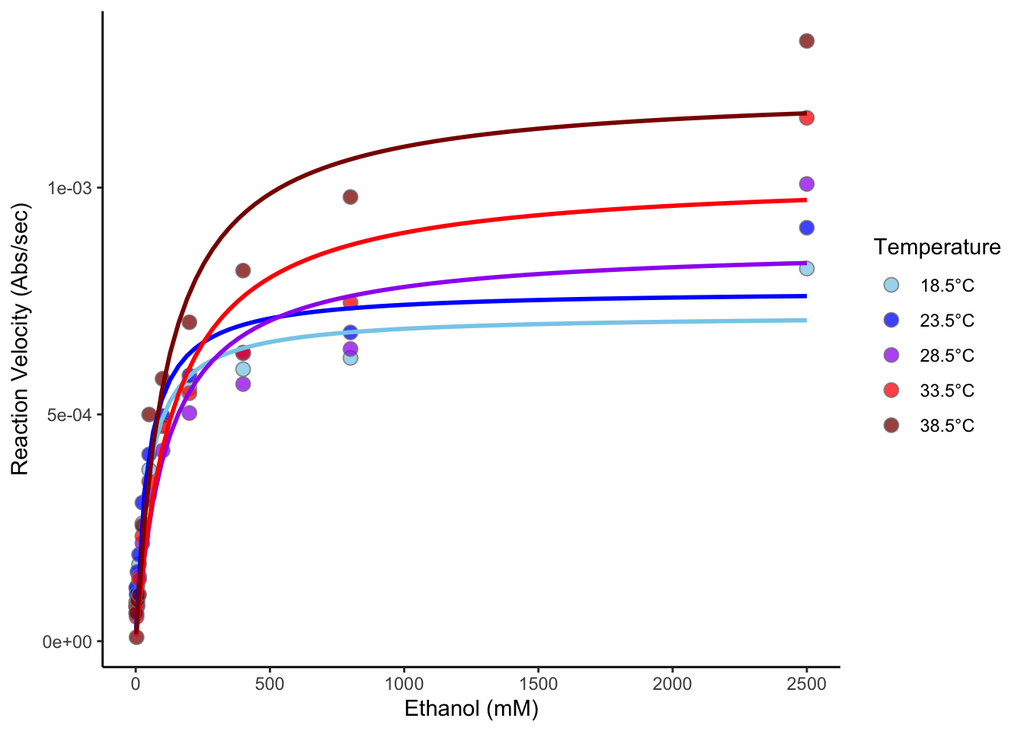

```r
# VTECK8 ADH enzyme
plot_mm_curve(data_velo_vt)
```

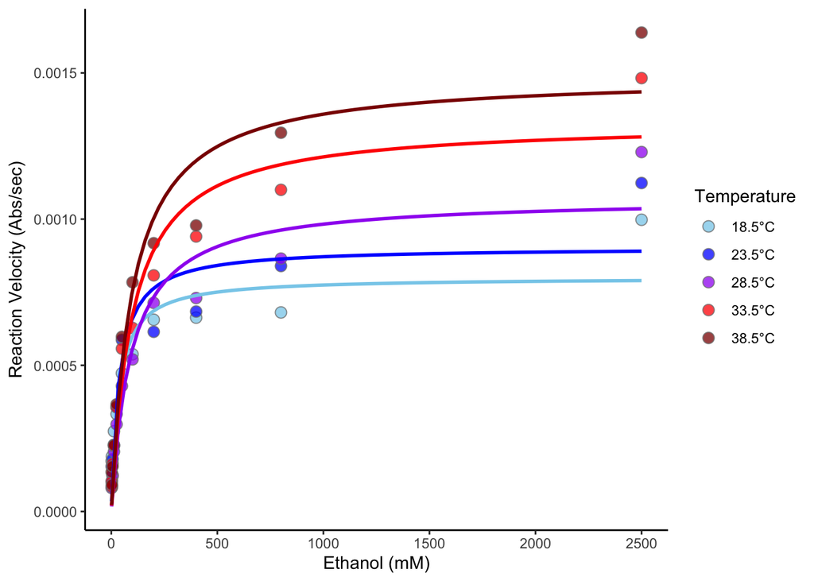

```r
# Chiapas ADH enzyme
plot_mm_curve(data_velo_chiapas)
```

## Plot K<sub>m</sub> values

```r
# Combine Km tibbles -----------------------------------------------------------
df_km_plot <- bind_rows("fast" = data_Km_Vm_f,
                        "slow" = data_Km_Vm_s,
                        "vt" = data_Km_Vm_vt,
                        "chiapas" = data_Km_Vm_chiapas,
                        .id = "enzyme") %>%
  mutate(enzyme = factor(enzyme, levels = c("vt", "chiapas", "fast", "slow"))) %>%
  select(enzyme, temp_group, term, estimate, std.error) %>%
  pivot_wider(names_from = term,
              values_from = c(estimate, std.error))

df_km_plot
```

```
## # A tibble: 20 x 6
## # Groups:   temp_group [5]
##    enzyme  temp_group estimate_Vmax estimate_Km std.error_Vmax std.error_Km
##    <fct>   <chr>              <dbl>       <dbl>          <dbl>        <dbl>
##  1 fast    18.5            0.00152         44.5      0.0000619         7.71
##  2 fast    23.5            0.00175         55.9      0.0000607         7.92
##  3 fast    28.5            0.00193         61.5      0.0000639         8.19
##  4 fast    33.5            0.00204         61.3      0.0000633         7.65
##  5 fast    38.5            0.00215         51.9      0.0000801         8.01
##  6 slow    18.5            0.00107         42.1      0.0000405         6.82
##  7 slow    23.5            0.00119         37.7      0.0000559         7.71
##  8 slow    28.5            0.00137         37.1      0.0000629         7.44
##  9 slow    33.5            0.00153         46.1      0.0000725         9.25
## 10 slow    38.5            0.00163         47.4      0.0000786         9.64
## 11 vt      18.5            0.000721        46.3      0.0000354         9.58
## 12 vt      23.5            0.000774        44.0      0.0000480        11.6
## 13 vt      28.5            0.000873       118.       0.0000806        38.8
## 14 vt      33.5            0.00103        141.       0.0000942        44.5
## 15 vt      38.5            0.00122        118.       0.0000805        27.7
## 16 chiapas 18.5            0.000800        33.3      0.0000639        11.8
## 17 chiapas 23.5            0.000903        36.7      0.0000770        14.1
## 18 chiapas 28.5            0.00107         92.6      0.0000821        26.5
## 19 chiapas 33.5            0.00133         97.6      0.0000926        25.1
## 20 chiapas 38.5            0.00149         97.1      0.000100         24.1
```

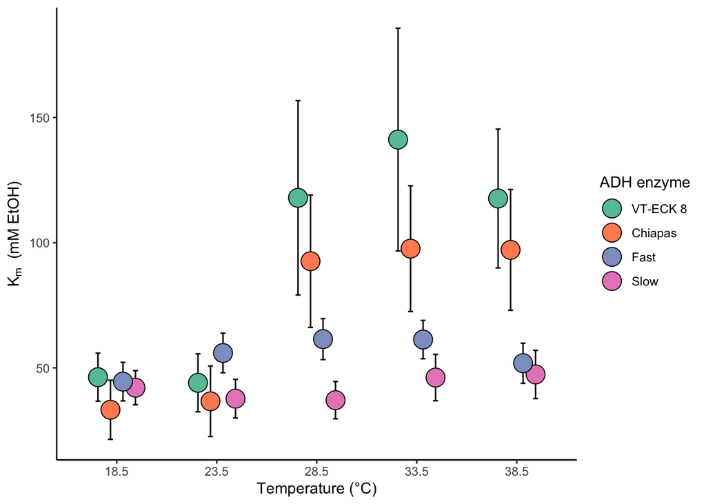

```r
# Plot all Km's on the same chart
plot_km(df_km_plot)
```

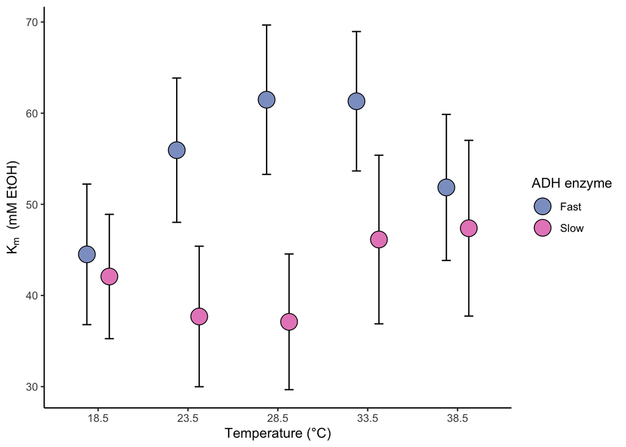

```r
# Plot all just fast and slow enzymes
plot_km(df_km_plot%>%
         filter(enzyme %in% c("fast", "slow" )),
        palette = brewer.pal(4, "Set2")[3:4],
        legend.labels = c("Fast", "Slow"))
```

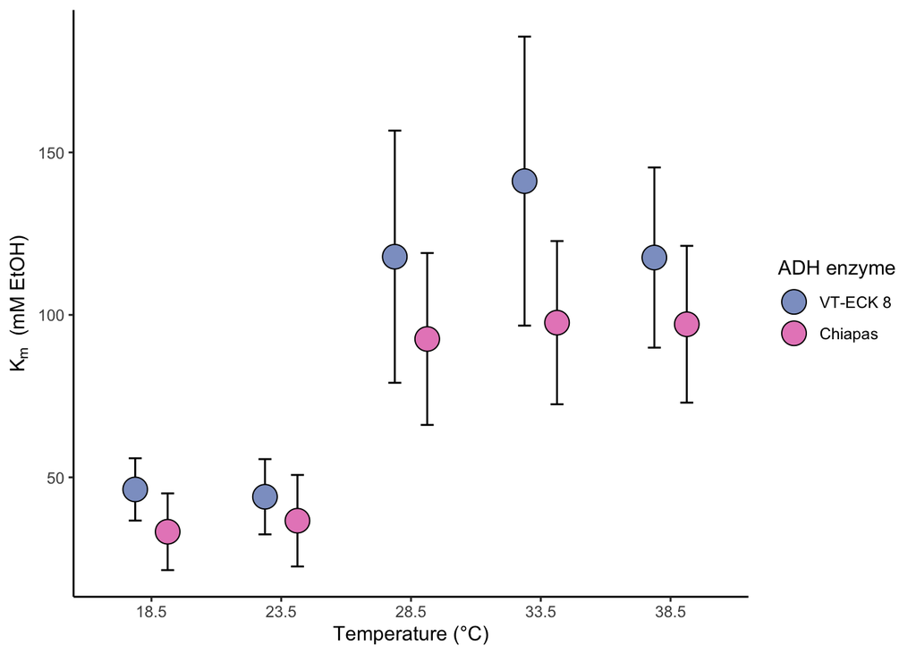

```r
# Plot all just vt and chiapas
plot_km(df_km_plot%>%
         filter(enzyme %in% c("vt", "chiapas" )),
        palette = brewer.pal(4, "Set2")[3:4],
        legend.labels = c("VT-ECK 8", "Chiapas"))
```